# Demo: Digital Demography and Data Science

Connor Gilroy

Copyright (c) 2021 Connor Gilroy. MIT Licensed. Full license terms [here](https://github.com/ccgilroy/csss563-demo/blob/master/LICENSE).

# Goals

1. To scrape data from the front end of any web page.
2. To access data from certain online sources via structured requests.
3. To collect social media data using a dedicated R package for Twitter.

The overarching goal is to expose you to different ways of collecting digital data for demographic research.

The approaches here, scaled up to collect more data over longer periods of time, are the main ones used for quantitative research projects with digital data. (The only other alternative is to persuade a company or collaborator to give you the data directly.)

# References

This demo draws on prior tutorials I’ve given, as well as courses and workshops by [Emilio Zagheni](https://github.com/ezagheni/IUSSP2017_Twitter_module), [Pablo Barberá](http://pablobarbera.com/POIR613/code/23-twitter-streaming-data-collection.html), [Rochelle Terman](https://plsc-31101.github.io/course/collecting-data-from-the-web.html), [Chris Bail](https://cbail.github.io/textasdata/screenscraping/rmarkdown/Screenscraping_in_R.html), and [Monica Alexander](https://mjalexander.github.io/social_media_workshop/).

# Setup

Load the following packages. (Install them if you don’t have them.)

```r
library(tidyverse) # general R data science tools
library(rvest) # for web scraping
library(httr) # for general API access
library(jsonlite) # for working with json-formatted responses
library(rtweet) # for Twitter API access
library(leaflet) # for maps
library(tidygeocoder) # for geocoding (bounding boxes)
library(tigris) # for geocoding (Census GEOIDs)
```

# Webscraping with `rvest`

As an example, we’ll scrape the UW sociology department’s directory: https://soc.washington.edu/people. Our goal will be to grab the list of people in the department, and turn it into an R data frame.

We can do this because web pages are written in HTML, which has a hierarchical tree structure of named elements. Each website is different, but once we figure out the structure we can extract whatever we want.

Open the sociology web page in your browser. We want to view the underlying HTML—we’ll need to look at it to figure out what parts of the page to extract. In Chrome, you can do this by right-clicking and selecting “Inspect.”

#content-inner > div > div.view-content > table

#content-inner > div > div.view-content > table

Mouse over the table on the page and find it in the html. Right-click on the `<table>` tag to copy the *CSS selector*, which is a way of uniquely identifying that element of the page. (XPath is an alternative.) We’ll use that identifier to pull the table out of the page. This selector identifies the table:

`#content-inner > div > div.view-content > table`

[That selector means “a table inside a div with class view-content inside another div inside something with id content-inner.”]

Now, let’s switch back to R. First, to download the page into R:

```r
library(rvest)
uw_soc <- read_html("https://soc.washington.edu/people")

uw_soc
```

```
## {html_document}
## <html lang="en" dir="ltr">
## [1] <head>\n<meta http-equiv="Content-Type" content="text/html; charset=UTF-8 ...
## [2] <body class="html not-front not-logged-in one-sidebar sidebar-second page ...
```

```r
# to see the whole html structure (it's long!):
# html_structure(uw_soc)
```

Find the table, using the CSS selector:

```r
table_selector <- "#content-inner > div > div.view-content > table"

people_table_node <- html_node(uw_soc,
                               css = table_selector)

people_table_node
```

```
## {html_node}
## <table class="views-table cols-4" summary="Basic contact information for department faculty, staff, and grad students.">
## [1] <thead><tr>\n<th class="views-field views-field-title" scope="col">\n     ...
## [2] <tbody>\n<tr class="odd views-row-first">\n<td class="views-field views-f ...
```

Convert the table into a data frame:

```r
people_table <- html_table(people_table_node)

people_table <- as_tibble(people_table)

names(people_table)
```

```
## [1] "Name"          "Title"         "Email / Phone" "Office Hours"
```

```r
nrow(people_table)
```

```
## [1] 101
```

Let’s look at the distribution of department members by title:

```r
people_table %>%
  count(Title) %>%
  arrange(desc(n))
```

```
## # A tibble: 16 x 2
##    Title                                    n
##    <chr>                                <int>
##  1 Graduate Student                        49
##  2 Emeritus Faculty                        18
##  3 Professor                                9
##  4 Associate Professor                      4
##  5 Main Office                              4
##  6 Student Services                         4
##  7 Assistant Professor                      3
##  8 Technical Support                        2
##  9 Affiliate, Research Staff                1
## 10 Assistant Teaching Professor             1
## 11 Assistant Teaching Professor, Alumna     1
## 12 Associate Teaching Professor             1
## 13 Chair, Professor                         1
## 14 Graduate Student, Student Services       1
## 15 Teaching Assistant                       1
## 16 Visiting Faculty                         1
```

**Note:** Of course, not everything online is a table. You might find structured data in other formats, and you can use selectors to pull specific fields.

**Going further with webscraping:**

- Some web pages are complicated and dynamic. For these, you can use **Selenium** to interact with the web browser (to click buttons, for example). Selenium works with multiple programming languages and has an R interface, `RSelenium`.
- **Helena** is a tool created by Sarah Chasins, a CS researcher, to help academics scrape data more easily. Kyle Crowder has a team of current and former graduate students working on using it to scrape rental data from Craigslist. Ian Kennedy & Chris Hess are two team members.

# APIs with `httr`

```r
library(httr)
library(jsonlite)
```

## http verbs and statuses

HTTP is a protocol which underlies the web. You make a *request* to a particular URL and get a *response* back.

The methods for making requests are verbs: GET, POST, PUT, DELETE…

A basic example:

```r
r <- GET("https://http.cat/404")
r
```

```
## Response [https://http.cat/404]
##   Date: 2021-05-28 23:50
##   Status: 200
##   Content-Type: image/jpeg
##   Size: 79.2 kB
## <BINARY BODY>
```

```r
status_code(r)
```

```
## [1] 200
```

```r
r_body <- content(r, as = 'raw')
head(r_body)
```

```
## [1] ff d8 ff e0 00 10
```

```r
write_file(r_body, "404.jpg")
```

## paths and queries

The World Bank has a database of information about different countries: https://datahelpdesk.worldbank.org/knowledgebase/topics/125589

To get data from the World Bank API, we need to build a url. In addition to the base website name, this can have two trailing components:

- a path, separated with slashes (like `/path/to/resource`)
- a query, separated with ? and & (like `?key1=value1&key2=value2`)

```r
# the base url (protocol + host)
wb_url <- "http://api.worldbank.org"

# the path to a particular country
wb_path <- str_c("v2", "country", "us", sep = "/")

# a query parameter telling the API what format we want
wb_query <- list(
  format = "json"
)
```

```r
r1 <- GET(wb_url, path = wb_path, query = wb_query)
r1
```

```
## Response [http://api.worldbank.org/v2/country/us?format=json]
##   Date: 2021-05-28 23:50
##   Status: 200
##   Content-Type: application/json;charset=utf-8
##   Size: 421 B
```

```r
r1_v2 <- GET("http://api.worldbank.org/v2/country/us?format=json")
```

```r
prettify(content(r1, as = "text"))
```

```
## [
##     {
##         "page": 1,
##         "pages": 1,
##         "per_page": "50",
##         "total": 1
##     },
##     [
##         {
##             "id": "USA",
##             "iso2Code": "US",
##             "name": "United States",
##             "region": {
##                 "id": "NAC",
##                 "iso2code": "XU",
##                 "value": "North America"
##             },
##             "adminregion": {
##                 "id": "",
##                 "iso2code": "",
##                 "value": ""
##             },
##             "incomeLevel": {
##                 "id": "HIC",
##                 "iso2code": "XD",
##                 "value": "High income"
##             },
##             "lendingType": {
##                 "id": "LNX",
##                 "iso2code": "XX",
##                 "value": "Not classified"
##             },
##             "capitalCity": "Washington D.C.",
##             "longitude": "-77.032",
##             "latitude": "38.8895"
##         }
##     ]
## ]
##
```

We can read the [API documentation](https://datahelpdesk.worldbank.org/knowledgebase/articles/889392-about-the-indicators-api-documentation) and find out that `SP.POP.TOTL` is the indicator for a country’s population. We then build a new path to access that indicator:

```r
wb_path_2 <- str_c("v2", "country", "us", "indicators", "SP.POP.TOTL", sep = "/")

wb_path_2
```

```
## [1] "v2/country/us/indicators/SP.POP.TOTL"
```

Make the request:

```r
r2 <- GET(wb_url, path = wb_path_2, query = wb_query)
```

And look at the response:

```r
prettify(content(r2, as = "text"))
```

[output not shown]

```r
r2_body <- jsonlite::fromJSON(content(r2, as = "text"))

d2 <- jsonlite::flatten(r2_body[[2]])

head(d2)
```

```
##   countryiso3code date     value unit obs_status decimal indicator.id
## 1             USA 2020        NA                       0  SP.POP.TOTL
## 2             USA 2019 328239523                       0  SP.POP.TOTL
## 3             USA 2018 326687501                       0  SP.POP.TOTL
## 4             USA 2017 324985539                       0  SP.POP.TOTL
## 5             USA 2016 322941311                       0  SP.POP.TOTL
## 6             USA 2015 320635163                       0  SP.POP.TOTL
##     indicator.value country.id country.value
## 1 Population, total         US United States
## 2 Population, total         US United States
## 3 Population, total         US United States
## 4 Population, total         US United States
## 5 Population, total         US United States
## 6 Population, total         US United States
```

```r
r2_body[[1]]
```

```
## $page
## [1] 1
##
## $pages
## [1] 2
##
## $per_page
## [1] 50
##
## $total
## [1] 61
##
## $sourceid
## [1] "2"
##
## $sourcename
## [1] "World Development Indicators"
##
## $lastupdated
## [1] "2021-05-25"
```

We can get the rest by adding a query parameter `page = 2`:

```r
wb_query_2 <- wb_query
wb_query_2$page = 2

# make request
r3 <- GET(wb_url, path = wb_path_2, query = wb_query_2)

# extract data frame
d3 <- jsonlite::flatten(jsonlite::fromJSON(content(r3, as = "text"))[[2]])

# combine data frames
d_complete <- bind_rows(d2, d3)
tail(d_complete)
```

```
##    countryiso3code date     value unit obs_status decimal indicator.id
## 56             USA 1965 194303000                       0  SP.POP.TOTL
## 57             USA 1964 191889000                       0  SP.POP.TOTL
## 58             USA 1963 189242000                       0  SP.POP.TOTL
## 59             USA 1962 186538000                       0  SP.POP.TOTL
## 60             USA 1961 183691000                       0  SP.POP.TOTL
## 61             USA 1960 180671000                       0  SP.POP.TOTL
##      indicator.value country.id country.value
## 56 Population, total         US United States
## 57 Population, total         US United States
## 58 Population, total         US United States
## 59 Population, total         US United States
## 60 Population, total         US United States
## 61 Population, total         US United States
```

Other general API examples:

- Yelp: https://github.com/ccgilroy/yelp-restaurants
- the New York Times: https://github.com/ccgilroy/nyt-api-httr-demo

# Twitter APIs with `rtweet`

Social media APIs often have dedicated packages to make it easier to use them. `rtweet` is the most current and flexible package for the Twitter APIs.

The World Bank API let us make requests without authenticating, but most APIs require some type of **authentication**. This allows APIs to revoke access or enforce limits on access. Often there’s a limit on how many requests you can make in a period of time, which is called *rate limiting*. The simplest form of authentication is an *API key*, which is essentially a password that you send with every request as a query parameter. Social media APIs typically have more complicated permissions, often based off of the *OAuth* standard.

To authenticate with `rtweet`, you will need a personal Twitter account. When you first run `stream_tweets()`, it will open a web browser to your Twitter account and ask you to authorize the rstats2twitter app.

This is much easier than creating your own developer app and obtaining an OAuth access token, which used to be the typical approach. You might still find yourself needing to do that for more complex tasks; read more about authentication in `vignette("auth", "rtweet")`.

**Note:** The first time I used `rtweet`, I ran into trouble with file permissions for my `.Renviron` file. I had to change ownership of that file to … myself. You may have similar issues to troubleshoot.

Twitter’s developer documentation for researchers describes some of the different endpoints, their uses, and limitations: https://developer.twitter.com/en/use-cases/academic-researchers/products-for-researchers

## the streaming API

Without a query, `stream_tweets()` returns a sample of real-time tweets. (There’s some previous research indicating that this sample might not be truly random, though that may have changed.)

```r
library(rtweet)

streamed_tweets <- stream_tweets(
  q = "",
  timeout = 10,
  parse = TRUE,
  file_name = "rtweet_stream.json"
)
```

```
## Streaming tweets for 10 seconds...
```

```
## Finished streaming tweets!
```

```r
names(streamed_tweets)
```

```
##  [1] "user_id"                 "status_id"
##  [3] "created_at"              "screen_name"
##  [5] "text"                    "source"
##  [7] "display_text_width"      "reply_to_status_id"
##  [9] "reply_to_user_id"        "reply_to_screen_name"
## [11] "is_quote"                "is_retweet"
## [13] "favorite_count"          "retweet_count"
## [15] "quote_count"             "reply_count"
## [17] "hashtags"                "symbols"
## [19] "urls_url"                "urls_t.co"
## [21] "urls_expanded_url"       "media_url"
## [23] "media_t.co"              "media_expanded_url"
## [25] "media_type"              "ext_media_url"
## [27] "ext_media_t.co"          "ext_media_expanded_url"
## [29] "ext_media_type"          "mentions_user_id"
```

[output cut: 30 more lines]

```r
streamed_tweets %>%
  count(lang) %>%
  arrange(desc(n))
```

```
## # A tibble: 18 x 2
##    lang      n
##    <chr> <int>
##  1 en       96
##  2 ja       63
##  3 es       55
##  4 und      37
##  5 ar       32
##  6 pt       31
##  7 th       13
##  8 in       11
##  9 ko        5
## 10 tr        4
## 11 fr        2
## 12 tl        2
## 13 ht        1
## 14 ne        1
## 15 nl        1
## 16 te        1
## 17 ur        1
## 18 zh        1
```

You can filter by topic, which delivers complete data rather than a sample (up to a 1% cap).

```r
streamed_tweets_filter <- stream_tweets(
  q = "statistics",
  timeout = 30,
  parse = TRUE,
  file_name = "rtweet_stream_filter.json"
)
```

```
## Streaming tweets for 30 seconds...
```

```
## Finished streaming tweets!
```

### geolocated tweets

For social science research purposes, often the most useful tweets are ones that are geolocated. (This is a small minority of tweets.) If you supply a geography, you’ll get geolocated tweets:

```r
streamed_tweets_geo <- stream_tweets(
  q = lookup_coords("usa"),
  timeout = 5,
  parse = TRUE,
  file_name = "rtweet_stream_geo.json",
)
```

```
## Streaming tweets for 5 seconds...
```

```
## Finished streaming tweets!
```

Extract coordinates with `lat_lng()`, and then plot them using the `leaflet` package:

```r
lat_lng(streamed_tweets_geo) %>%
  leaflet() %>%
  addTiles() %>%
  addCircles(popup = ~text)
```

```
## Assuming "lng" and "lat" are longitude and latitude, respectively
```

[interactive chart not shown]

(See this older tutorial for more on mapping: https://github.com/ccgilroy/mapping-twitter-data)

You can also supply coordinates manually using a *bounding box*:

```r
# Note: this code isn't run

# a bounding box for Washington state (looked up online)
# order is left, bottom, right, top
# same order as lookup_coords()
wa <- c(-124.8361, 45.5437, -116.9174, 49.0024)

streamed_tweets_wa <- stream_tweets(
  q = wa,
  timeout = 10,
  parse = TRUE,
  file_name = "rtweet_stream_wa.json",
)
```

Some bounding boxes are built into rtweet:

```r
lookup_coords("seattle us")
```

```
## $place
## [1] "seattle us"
##
## $box
## sw.lng.lng sw.lat.lat ne.lng.lng ne.lat.lat
##  122.28333   47.56667  122.38333   47.66667
##
## $point
##       lat       lng
##  47.61667 122.33333
##
## attr(,"class")
## [1] "coords" "list"
```

Others require a Google Maps API key.

Instead of `lookup_coords()`, you can use `tidygeocoder::geo()` to get bounding box information from OpenStreetMaps through the Nominatim API. This returns coordinates in a different order and format, so they need to be rearranged to work with `stream_tweets()`.

```r
# geocoding data for Washington state from Nominatim / OSM
wa2 <- geo(address = "Washington State", full_results = TRUE)

# order is bottom, top, left, right
wa2$boundingbox[[1]]
```

```
## [1] "45.5437226"   "49.0024392"   "-124.8360916" "-116.9174298"
```

```r
# so rearrange using indices (and convert from character to numeric)
wa2_bb <- as.numeric(wa2$boundingbox[[1]][c(3, 1, 4, 2)])
wa2_bb
```

```
## [1] -124.83609   45.54372 -116.91743   49.00244
```

```r
# again, not run
streamed_tweets_wa <- stream_tweets(
  q = wa2_bb,
  timeout = 10,
  parse = TRUE,
  file_name = "rtweet_stream_wa.json",
)
```

### geocoding to Census geographies

As of May 2021, you need tigris version 1.4 to geocode latitudes and longitudes to Census geographies using the Bureau’s geocoding API. (https://geocoding.geo.census.gov/)

```r
lat_lng(streamed_tweets_geo) %>%
  head(5) %>%
  select(user_id, status_id, text, lat, lon = lng) %>%
  append_geoid(geoid_type = "county") %>%
  select(lat, lon, geoid)
```

```
## # A tibble: 5 x 3
##     lat   lon geoid
##   <dbl> <dbl> <chr>
## 1  42.3 -71.4 25017
## 2  43.0 -77.2 36069
## 3  40.4 -82.7 39117
## 4  33.9 -98.5 48485
## 5  42.9 -85.9 26139
```

## the search API

`search_tweets()` finds tweets from the past ~7 days:

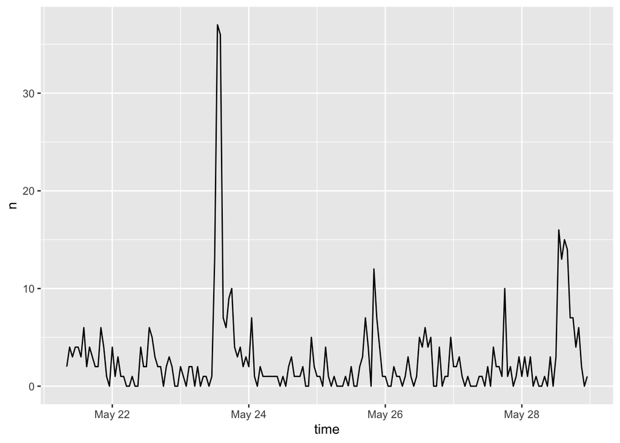

```r
searched_tweets <- search_tweets(
  q = "demography",
  n = 1000,
  geocode = lookup_coords("usa")
)

ts_plot(searched_tweets, by = "hour")
```

## Friends and followers

The Twitter API also allows collecting data on users rather than tweets. You can use this to build a network of friends and followers. In this case, I’ve created a list of accounts for 7 UW Sociology professors — you could imagine constructing a full list based on the data we webscraped in the very first activity. Which of these accounts follow *each other*?

```r
accounts <- read_lines("accounts.txt")

accounts_info <- lookup_users(accounts)

names(users_data(accounts_info))
```

```
##  [1] "user_id"                "screen_name"            "name"
##  [4] "location"               "description"            "url"
##  [7] "protected"              "followers_count"        "friends_count"
## [10] "listed_count"           "statuses_count"         "favourites_count"
## [13] "account_created_at"     "verified"               "profile_url"
## [16] "profile_expanded_url"   "account_lang"           "profile_banner_url"
## [19] "profile_background_url" "profile_image_url"
```

`get_friends()` retrieves who they follow:

```r
d_friends <-
  accounts_info %>%
  select(user_id, screen_name, name) %>%
  mutate(friends = map(user_id, get_friends))
```

Filter down to just those 7 accounts:

```r
d_edges <-
  d_friends %>%
  select(-user_id) %>%
  unnest(cols = c(friends)) %>%
  select(from = user, to = user_id) %>%
  filter(to %in% accounts_info$user_id)
```

tidygraph builds a network object from node and edge data frames:

```r
library(tidygraph)
g <- tbl_graph(nodes = users_data(accounts_info),
               edges = d_edges,
               node_key = "user_id")
```

ggraph plots the network:

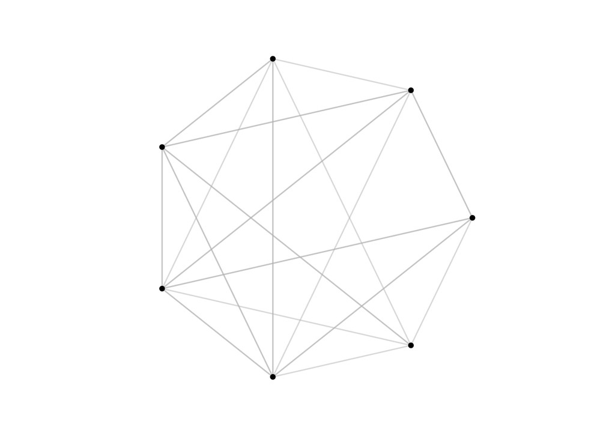

```r
library(ggraph)

ggraph(g, layout = "circle") +
  geom_edge_link(color = "gray", alpha = .5) +
  geom_node_point(color = "black") +
  # censoring user names; uncomment and re-run to see
  # geom_node_text(aes(label = screen_name)) +
  coord_equal() +
  xlim(-1.5, 1.5) +
  theme_graph()
```

## Alternative Twitter package - `streamR`

There’s a slightly older package for accessing the Twitter Streaming API called `streamR`, written by Pablo Barberá. If `rtweet` doesn’t work out for some of you, we’ll have a look at this code as an alternative.

For `streamR`, you will need a developer account, developer app, and access token. See here for a bit more on how to do that:

http://pablobarbera.com/POIR613/code/23-twitter-streaming-data-collection.html#authenticating

You need to keep your access token secret. Mine’s just in a separate file—even better would be to save it as an object in your global environment.

```r
library(ROAuth)
library(streamR)

my_oauth <- yaml::yaml.load_file("twitter_auth.yml")
names(my_oauth)
```

```r
# filter by keyword
filterStream(file.name = "streamr.json",
             track = "#rstats",
             oauth = my_oauth, timeout = 20)

tweets <- parseTweets("streamr.json")
head(tweets)
```

```r
# filter by geography
# Washington state bounding box
wa <- c(-124.8361, 45.5437, -116.9174, 49.0024)

filterStream(file.name = "streamr_wa.json",
             locations = wa,
             timeout = 60,
             oauth = my_oauth)

tweets_wa <- parseTweets("streamr_wa.json")
tweets_wa <- as_tibble(tweets_wa)
```

```r
# map tweets with the leaflet package
library(leaflet)
tweets_wa %>%
  select(lat, lon, text) %>%
  na.omit() %>%
  leaflet() %>%
  addTiles() %>%
  addCircleMarkers(popup = ~text)
```